# IODS course project

Joonas Kolstela

# Introduction to Open Data Science - Course Project

The course contains essential lessons in R from beginner to intermediate level. I am really looking forward to this course, but the amount of work is a bit scary along with other courses and my job. I am looking forward to learn smarter ways to use **R** and more about *statistical methods*. I learned about this course from an email from University of Helsinki with a listing of starting courses.

[link](https://github.com/Joonasko/IODS-project.git)

```r
# This is a so-called "R chunk" where you can write R code.

date()
```

```
## [1] "Mon Dec 12 16:02:35 2022"
```

The exercise set and the first chapters were a good introduction into the topic. It’s good to have some “official” recommendations on how to write code, instead of just learning from github and stackoverflow. For some reason plotting has always been quite difficult for me, so it’s really helpful to start learning ggplot. I think the learning curve is quite steep, but worthwile in the long run.

# Chapter 2 - first data wrangling and analysis of the learning2014 dataset

## Work description and results

In this exercise I downloaded the dataset containing the international survey results of Approaches to Learning from the course Introduction to Social Statistics, found here: http://www.helsinki.fi/~kvehkala/JYTmooc/JYTOPKYS2-meta.txt  
The dataset contains information about the students such as age and gender, and information about their attitudes towards the course assignments and how well they performed.

I performed some necessary data wrangling, in which we combined some of the questionnaire data into larger sets depicting deep, strategic and surface level question types. We also removed all students who scored 0 points from their assignments from the dataset.

After plotting the data and doing an overview of it and its correlations with a matrix plot, I noticed that from the different variables, attitude and performance in strategic questions had higher correlation with the points (attitude 0.437 and strategic questions 0.146) than other variables. After testing a linear regression model with age, strategic questions and attitude as explaining variables to the points, it was clear that only the student’s attitude had significance in the model.

After removing the age and strategic questions from the linear model, the resulting explanatory variable had a p-value of 4.12e-09, meaning that it is significant. The residual values lean a bit on the negative side, meaning that the model underestimates certain points. The t-value of 6.214 indicates that we can say that a relationship between attitude and points scored exists.

however, the multiple R-squared has a quite low value of 0.1906, meaning that our predictor (attitude) explains only 19 % of the variance in our response variable (points). Finally, the F-statistic of 38.61 is high enough to confirm that there is a relationship between attitude and points. **My conclusion is, that while the attitude has the highest correlation with the points of all of the variables, there are still some unfound variables that could be used together with attitude to explain the variation.**

```r
date()
```

```
## [1] "Mon Dec 12 16:02:35 2022"
```

Here we go again…

# Chapter 3 - data wrangling and analysis of the Portuguese student performance dataset

Joonas Kolstela, 17.11.2022 18:53, script for datawrangling and analysis of the UCI machine learning student performance data. Data source: https://archive.ics.uci.edu/ml/datasets/Student+Performance

## Reading, combining and checking structure of the data

These datasets consists of data from two questionnaires from Portuguese schools.  
The first dataset contains answers from the subject of mathematics and the other from Portuguese language.

```r
library(dplyr)
```

```r
library(ggplot2)
library(GGally)
setwd("D:/R/IODS-project/")

# Reading the data.

student_mat <- read.csv("data/student-mat.csv", sep = ";")
student_por <- read.csv("data/student-por.csv", sep = ";")

# Check structure and dimensions:
str(student_mat) # 395 rows, 33 columns containing character and integer variables.
```

```
## 'data.frame':    395 obs. of  33 variables:
##  $ school    : chr  "GP" "GP" "GP" "GP" ...
##  $ sex       : chr  "F" "F" "F" "F" ...
##  $ age       : int  18 17 15 15 16 16 16 17 15 15 ...
##  $ address   : chr  "U" "U" "U" "U" ...
##  $ famsize   : chr  "GT3" "GT3" "LE3" "GT3" ...
##  $ Pstatus   : chr  "A" "T" "T" "T" ...
##  $ Medu      : int  4 1 1 4 3 4 2 4 3 3 ...
##  $ Fedu      : int  4 1 1 2 3 3 2 4 2 4 ...
##  $ Mjob      : chr  "at_home" "at_home" "at_home" "health" ...
##  $ Fjob      : chr  "teacher" "other" "other" "services" ...
##  $ reason    : chr  "course" "course" "other" "home" ...
##  $ guardian  : chr  "mother" "father" "mother" "mother" ...
##  $ traveltime: int  2 1 1 1 1 1 1 2 1 1 ...
##  $ studytime : int  2 2 2 3 2 2 2 2 2 2 ...
```

[output cut: 19 more lines]

```r
str(student_por) # 649 rows, 33 columns containing character and integer variables.
```

```
## 'data.frame':    649 obs. of  33 variables:
##  $ school    : chr  "GP" "GP" "GP" "GP" ...
##  $ sex       : chr  "F" "F" "F" "F" ...
##  $ age       : int  18 17 15 15 16 16 16 17 15 15 ...
##  $ address   : chr  "U" "U" "U" "U" ...
##  $ famsize   : chr  "GT3" "GT3" "LE3" "GT3" ...
##  $ Pstatus   : chr  "A" "T" "T" "T" ...
##  $ Medu      : int  4 1 1 4 3 4 2 4 3 3 ...
##  $ Fedu      : int  4 1 1 2 3 3 2 4 2 4 ...
##  $ Mjob      : chr  "at_home" "at_home" "at_home" "health" ...
##  $ Fjob      : chr  "teacher" "other" "other" "services" ...
##  $ reason    : chr  "course" "course" "other" "home" ...
##  $ guardian  : chr  "mother" "father" "mother" "mother" ...
##  $ traveltime: int  2 1 1 1 1 1 1 2 1 1 ...
##  $ studytime : int  2 2 2 3 2 2 2 2 2 2 ...
```

[output cut: 19 more lines]

```r
# Join the data sets without "failures", "paid", "absences", "G1", "G2", "G3".
# Keep only students found in both data sets.

free_cols <- c("failures","paid", "absences", "G1", "G2", "G3")
join_cols <- setdiff(colnames(student_por), free_cols)

# Join the two data sets by the selected identifiers.
math_por <- inner_join(student_mat, student_por, by = join_cols)
#head(math_por)
#glimpse(math_por)

alc <- select(math_por, all_of(join_cols))
for(col_name in free_cols) {
  # select two columns from 'math_por' with the same original name
  two_cols <- select(math_por, starts_with(col_name))
  # select the first column vector of those two columns
  first_col <- select(two_cols, 1)[[1]]

  # then, enter the if-else structure!
  # if that first column vector is numeric...
  if(is.numeric(first_col)) {
    # take a rounded average of each row of the two columns and
    # add the resulting vector to the alc data frame
    alc[col_name] <- round(rowMeans(two_cols))
  } else { # else (if the first column vector was not numeric)...
    # add the first column vector to the alc data frame
    alc[col_name] <- two_cols[1]
  }
}


alc <- mutate(alc, alc_use = (Dalc + Walc) / 2)

# Define a new logical column 'high_use'.
alc <- mutate(alc, high_use = alc_use > 2)

# Writing the new combined data as csv file.
write.csv(alc, "data/alc.csv", row.names = FALSE)
```

# Data analysis part

```r
# Reading the data back into R.
alc <- read.csv("data/alc.csv")

print(str(alc))
```

```
## 'data.frame':    370 obs. of  35 variables:
##  $ school    : chr  "GP" "GP" "GP" "GP" ...
##  $ sex       : chr  "F" "F" "F" "F" ...
##  $ age       : int  18 17 15 15 16 16 16 17 15 15 ...
##  $ address   : chr  "U" "U" "U" "U" ...
##  $ famsize   : chr  "GT3" "GT3" "LE3" "GT3" ...
##  $ Pstatus   : chr  "A" "T" "T" "T" ...
##  $ Medu      : int  4 1 1 4 3 4 2 4 3 3 ...
##  $ Fedu      : int  4 1 1 2 3 3 2 4 2 4 ...
##  $ Mjob      : chr  "at_home" "at_home" "at_home" "health" ...
##  $ Fjob      : chr  "teacher" "other" "other" "services" ...
##  $ reason    : chr  "course" "course" "other" "home" ...
##  $ guardian  : chr  "mother" "father" "mother" "mother" ...
##  $ traveltime: int  2 1 1 1 1 1 1 2 1 1 ...
##  $ studytime : int  2 2 2 3 2 2 2 2 2 2 ...
```

[output cut: 22 more lines]

```r
print(colnames(alc))
```

```
##  [1] "school"     "sex"        "age"        "address"    "famsize"
##  [6] "Pstatus"    "Medu"       "Fedu"       "Mjob"       "Fjob"
## [11] "reason"     "guardian"   "traveltime" "studytime"  "schoolsup"
## [16] "famsup"     "activities" "nursery"    "higher"     "internet"
## [21] "romantic"   "famrel"     "freetime"   "goout"      "Dalc"
## [26] "Walc"       "health"     "failures"   "paid"       "absences"
## [31] "G1"         "G2"         "G3"         "alc_use"    "high_use"
```

The variables found in these datasets contain information about the students, their families, hobbies etc. totalling in 35 different variables for each of the 370 students.

### Hypothesis about the data and the relationships between selected 4 variables and amount of drinking

I found the differences between men and women so interesting that I decided to keep them in the following comparison plots. I selected the sex, family relation, going out and mothers education (and out of curiosity the fathers education).  
My hypothesis for these are as follows:  
1. On average, men drink more and those that do score worse in the final grades (G3).  
2. Higher quality of family relation helps prevent higher alcohol usage.  
3. People who go out more have more likely high alcohol usage.  
4. A high education level for the mother lowers the likelyhood of high alcohol usage.

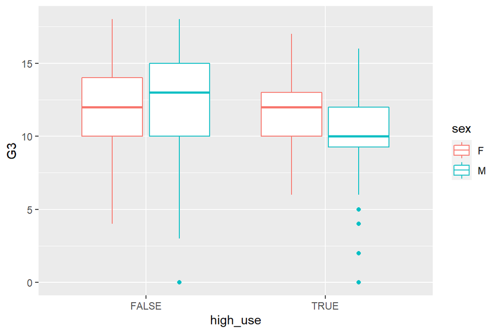

```r
# High use and gender.
g1 <- ggplot(alc, aes(x = high_use, y = G3, col = sex))
g1 + geom_boxplot()
```

Students who did not have high use had a better final grade than those who did. However, men who had high use had had worse final grades than any other group. I find it quite interesting that the effect of high alcohol use in women to their final grade is much lower than what it is on men.

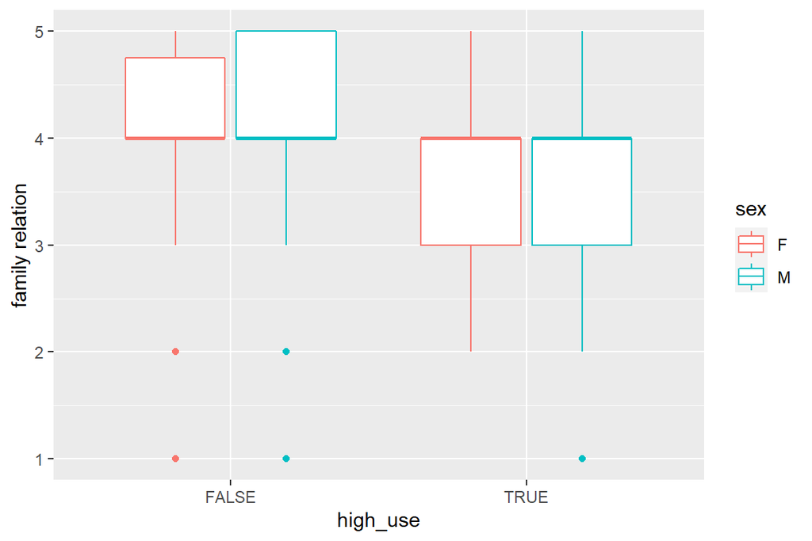

```r
# High use and family relation.
g1 <- ggplot(alc, aes(x = high_use, y = famrel, col = sex))
g1 + geom_boxplot() + ylab("family relation")
```

Better family relations seem to protect from higher alcohol use as suspected. The importance seems a bit higher for men than women.

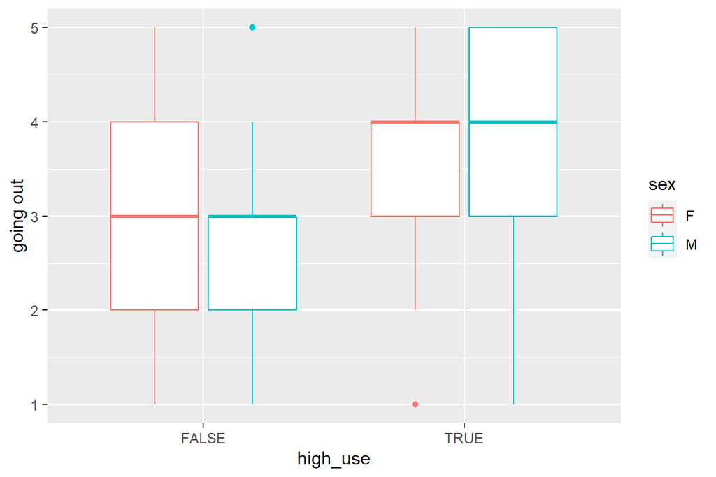

```r
# High use and going out.
g1 <- ggplot(alc, aes(x = high_use, y = goout, col = sex))
g1 + geom_boxplot() + ylab("going out")
```

As suspected, people who go out more have a higher chance of having high use. However, this is not so clear for women. Unlike men, women who go out more do not necessarily have high use.

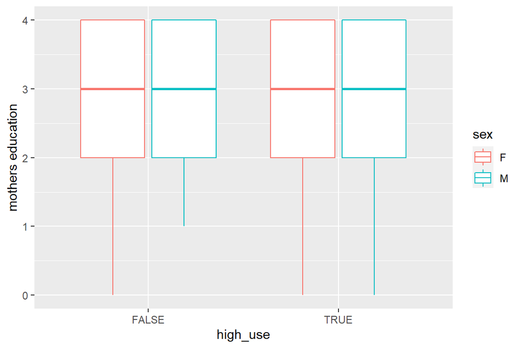

```r
# High use and mothers education.
g1 <- ggplot(alc, aes(x = high_use, y = Medu, col = sex))
g1 + geom_boxplot() + ylab("mothers education")
```

Mothers education does not seem to have any major effect on the high use. Effects are almost identical between men and women. My hypothesis seems to have been wrong.

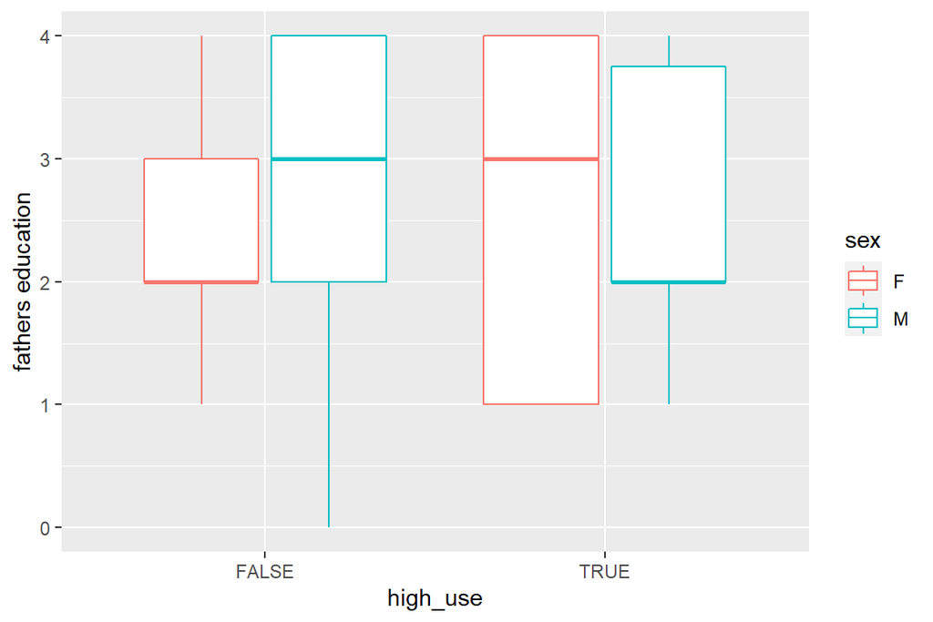

```r
# Had to compare to effect of fathers level of education:
g1 <- ggplot(alc, aes(x = high_use, y = Fedu, col = sex))
g1 + geom_boxplot() + ylab("fathers education")
```

The fathers level of education has a much higher variance compared to the mothers. This seems to mostly have an effect on women, for men the effect is not as clear.

### Coefficients and their meaning on the hypothesis

```r
m <- glm(high_use ~ sex+famrel+goout+Medu+Fedu, data = alc, family = "binomial")
summary(m)
```

```
##
## Call:
## glm(formula = high_use ~ sex + famrel + goout + Medu + Fedu,
##     family = "binomial", data = alc)
##
## Deviance Residuals:
##     Min       1Q   Median       3Q      Max
## -1.5697  -0.7918  -0.5236   0.8305   2.5679
##
## Coefficients:
##             Estimate Std. Error z value Pr(>|z|)
## (Intercept) -2.04688    0.72491  -2.824  0.00475 **
## sexM         1.01001    0.25737   3.924 8.70e-05 ***
## famrel      -0.44041    0.14033  -3.138  0.00170 **
## goout        0.80551    0.12313   6.542 6.07e-11 ***
## Medu        -0.14711    0.15124  -0.973  0.33072
## Fedu         0.06164    0.15151   0.407  0.68414
## ---
## Signif. codes:  0 '***' 0.001 '**' 0.01 '*' 0.05 '.' 0.1 ' ' 1
##
## (Dispersion parameter for binomial family taken to be 1)
##
##     Null deviance: 452.04  on 369  degrees of freedom
## Residual deviance: 378.08  on 364  degrees of freedom
## AIC: 390.08
##
## Number of Fisher Scoring iterations: 4
```

```r
confint(m)
```

```
##                  2.5 %     97.5 %
## (Intercept) -3.5072153 -0.6569855
## sexM         0.5115198  1.5225798
## famrel      -0.7193598 -0.1674320
## goout        0.5711044  1.0548826
## Medu        -0.4459863  0.1489973
## Fedu        -0.2346795  0.3613341
```

### Odds ratios and confidence intervals

```r
# compute odds ratios (OR)
OR <- coef(m) %>% exp

# compute confidence intervals (CI)
CI <- confint(m)
# print out the odds ratios with their confidence intervals
cbind(OR, CI)
```

```
##                    OR      2.5 %     97.5 %
## (Intercept) 0.1291376 -3.5072153 -0.6569855
## sexM        2.7456265  0.5115198  1.5225798
## famrel      0.6437727 -0.7193598 -0.1674320
## goout       2.2378460  0.5711044  1.0548826
## Medu        0.8632017 -0.4459863  0.1489973
## Fedu        1.0635774 -0.2346795  0.3613341
```

```r
# Fitting the model with significant variables.
m <- glm(high_use ~ sex+famrel+goout, data = alc, family = "binomial")

# predict() the probability of high_use
probabilities <- predict(m, type = "response")

# add the predicted probabilities to 'alc'
alc <- mutate(alc, probability = probabilities)

# use the probabilities to make a prediction of high_use
alc <- mutate(alc, prediction = probability > 0.5)

# see the last ten original classes, predicted probabilities, and class predictions
select(alc, failures, absences, sex, high_use, probability, prediction) %>% tail(10)
```

```
##     failures absences sex high_use probability prediction
## 361        0        3   M    FALSE  0.34478448      FALSE
## 362        1        0   M    FALSE  0.19155369      FALSE
## 363        1        7   M     TRUE  0.25406225      FALSE
## 364        0        1   F    FALSE  0.11228115      FALSE
## 365        0        6   F    FALSE  0.16347027      FALSE
## 366        1        2   F    FALSE  0.05388304      FALSE
## 367        0        2   F    FALSE  0.30264598      FALSE
## 368        0        3   F    FALSE  0.12748520      FALSE
## 369        0        4   M     TRUE  0.86102082       TRUE
## 370        0        2   M     TRUE  0.09640288      FALSE
```

```r
# tabulate the target variable versus the predictions
table(high_use = alc$high_use, prediction = alc$prediction)
```

```
##         prediction
## high_use FALSE TRUE
##    FALSE   241   18
##    TRUE     62   49
```

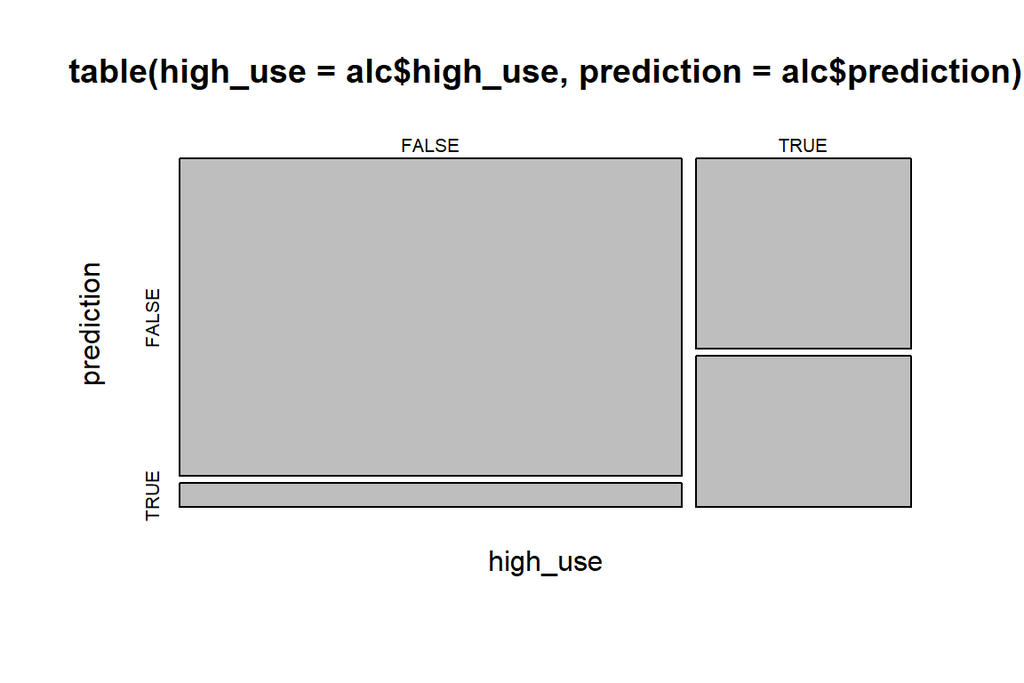

```r
plot(table(high_use = alc$high_use, prediction = alc$prediction))
```

```r
loss_func <- function(class, prob) {
  n_wrong <- abs(class - prob) > 0.5
  mean(n_wrong)
}

# call loss_func to compute the average number of wrong predictions in the (training) data
loss_func(class = alc$high_use, prob = alc$probability)
```

```
## [1] 0.2162162
```

**On average, we will get ~22 % of the predictions wrong in the training data. The model seems to do well when predicting false, but seems to underestimate the true predictions.**

# Chapter 4 - Data analysis of the Boston dataset and data wrangling of chapter 5 data

## Exploring the dataset

```r
# Loading packages.
library(dplyr)
library(MASS)
```

```r
library(tidyr)
library(corrplot)
library(ggplot2)
library(GGally)
# Loading the Boston dataset from MASS package.
data(Boston)

# Exploring the structure and dimensions of the dataset.
str(Boston)
```

```
## 'data.frame':    506 obs. of  14 variables:
##  $ crim   : num  0.00632 0.02731 0.02729 0.03237 0.06905 ...
##  $ zn     : num  18 0 0 0 0 0 12.5 12.5 12.5 12.5 ...
##  $ indus  : num  2.31 7.07 7.07 2.18 2.18 2.18 7.87 7.87 7.87 7.87 ...
##  $ chas   : int  0 0 0 0 0 0 0 0 0 0 ...
##  $ nox    : num  0.538 0.469 0.469 0.458 0.458 0.458 0.524 0.524 0.524 0.524 ...
##  $ rm     : num  6.58 6.42 7.18 7 7.15 ...
##  $ age    : num  65.2 78.9 61.1 45.8 54.2 58.7 66.6 96.1 100 85.9 ...
##  $ dis    : num  4.09 4.97 4.97 6.06 6.06 ...
##  $ rad    : int  1 2 2 3 3 3 5 5 5 5 ...
##  $ tax    : num  296 242 242 222 222 222 311 311 311 311 ...
##  $ ptratio: num  15.3 17.8 17.8 18.7 18.7 18.7 15.2 15.2 15.2 15.2 ...
##  $ black  : num  397 397 393 395 397 ...
##  $ lstat  : num  4.98 9.14 4.03 2.94 5.33 ...
##  $ medv   : num  24 21.6 34.7 33.4 36.2 28.7 22.9 27.1 16.5 18.9 ...
```

```r
dim(Boston)
```

```
## [1] 506  14
```

The Boston dataset depicts housing values in suburbs of Boston.  
Dataset includes variables such as crime rates, taxation rates, accessibility to radial highways and median values of owner-occupied homes.  
The variables consist of numerical values, and it has 506 rows and 14 columns.